# Semi-synthetic DA data - Mouse Gastrulation atlas

### Louvain

[figure not shown]

[output not shown]

[output cut: 990 more lines]

With Seurat

### Milo

Pick K using within/between cluster distance

```r
dim(as.matrix(nhoods_mat[1:3000,1:100]) %*% X_pca_ixs[1:100,])
```

```
[1] 3000   30
```

[figure not shown]

Compare with MELD

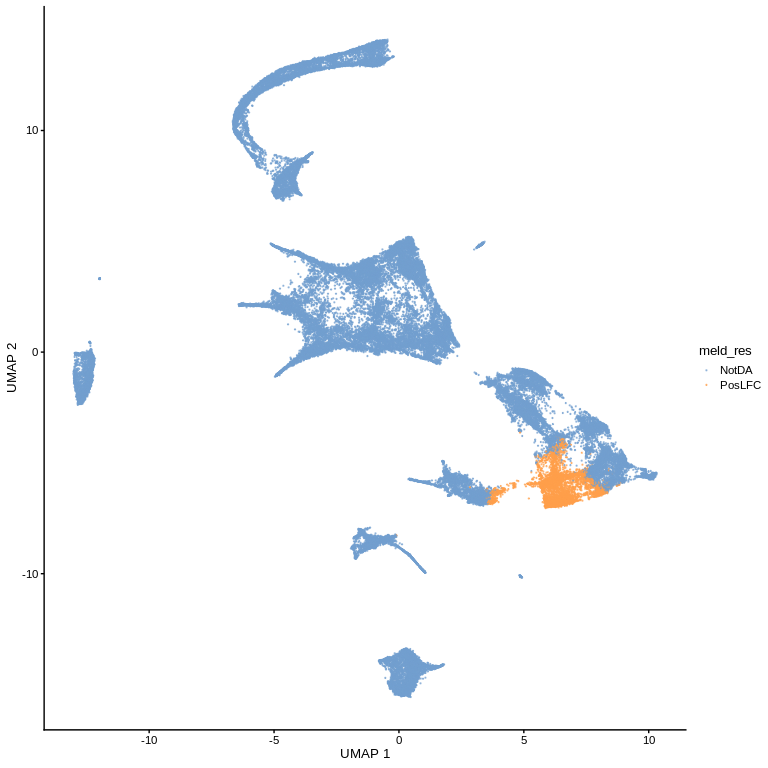

```r
meld_out <- run_meld_reticulate(embryo_sce, condition_col="synth_labels", sample_col="synth_samples", reduced.dim="pca.corrected",
         k=50)

embryo_sce$meld_res <- meld2output(meld_out, out_type = "labels")

plotReducedDim(embryo_sce, dimred="UMAP", colour_by="meld_res", point_size=0.2)
```

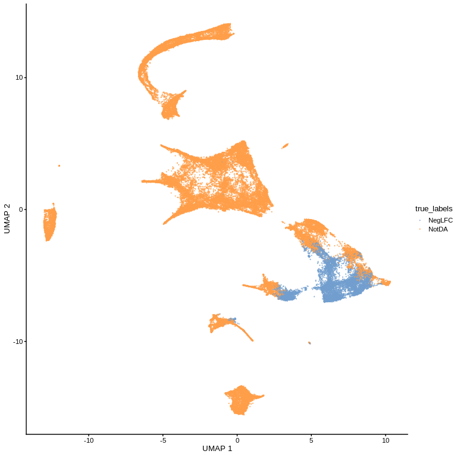

```r
plotReducedDim(embryo_sce, dimred="UMAP", colour_by="true_labels", point_size=0.2)
```

```r
## Make design matrix
sample_col = "synth_samples"
condition_col = "synth_labels"
batch_col = NULL
design_df <- as.tibble(colData(embryo_sce)[c(sample_col, condition_col, batch_col)]) %>%
    distinct() %>%
    column_to_rownames(sample_col)
  if (is.null(batch_col)) {
    design <- formula(paste('~', condition_col, collapse = ' '))
  } else {
    design <- formula(paste('~', batch_col, "+", condition_col, collapse = ' '))
  }

milo_ls <- lapply(milo_ls, function(m){
  ## Test DA
  m <- countCells(m, meta.data = data.frame(colData(m)), sample='synth_samples')
  m <- calcNhoodDistance(m, d=30, reduced.dim = "pca.corrected")
  DA_results <- testNhoods(m, design = design, design.df = design_df)
  return(list(Milo=m, da_res=DA_results))
})

milo_outcome <- lapply(seq_along(milo_ls), function(i)
  data.frame(pred=milo2output(milo_ls[[i]]$Milo, milo_ls[[i]]$da_res, out_type="labels"),
             true=milo_ls$`20`$Milo$true_labels,
             method=names(milo_ls)[i])
  ) %>%
  purrr::reduce(bind_rows) %>%
  calculate_outcome()

milo_outcome %>%
  ggplot(aes(method, Power)) + geom_point()

milo_outcome %>%
  ggplot(aes(method, TPR)) + geom_point()
```

```r
milo_out2 <- run_milo(embryo_sce, condition_col="synth_labels", sample_col="synth_samples", reduced.dim="pca.corrected",
         k=30, prop=0.1)

milo_out2$Milo <- buildNhoodGraph(milo_out2$Milo)

hist(rowSums(milo_out2$Milo@nhoods), breaks=100)

milo_out2$DAres %>%
  ggplot(aes(logFC, - log10(SpatialFDR))) + geom_point()
plotNhoodSizeHist(milo_out2$Milo) /
  plotNhoodGraphDA(milo_out2$Milo, milo_out2$DAres)
```

### MELD

```r
meld_res_ls <- lapply(seq(20,50, by = 10), function(k){
  meld_res <- run_meld_reticulate(embryo_sce, condition_col="synth_labels", sample_col="synth_samples", reduced.dim = "pca.corrected", d=30, k=k)
  meld_out <- meld2output(meld_res, out_type = "labels")
  meld_out
})

lapply(meld_res_ls)

# meld_outcome <-
  lapply(seq_along(meld_res_ls), function(i)
  data.frame(pred=meld_res_ls[[i]],
             true=embryo_sce$true_labels,
             method=seq(20,50, by = 10)[i])
  ) %>%
    purrr::reduce(bind_rows) %>%
    mutate(pred=as.character(pred)) %>%
    mutate(pred=case_when(pred=="PosLFC" ~ "NegLFC",
                        pred=="NegLFC" ~ "PosLFC",
                        TRUE ~ pred)) %>%
    mutate(outcome=case_when(true==pred & pred!="NotDA" ~ 'TP',
                             true!=pred & pred!="NotDA" ~ 'FP',
                             true!=pred & pred=="NotDA" ~ 'FN',
                             true==pred & pred=="NotDA"  ~ "TN"
    )) %>%
    group_by(method, outcome) %>%
    summarise(n=n()) %>%
    pivot_wider(id_cols=method, names_from=outcome, values_from=n, values_fill=0) %>%
    mutate(TPR=TP/(TP+FP), FPR=FP/(TP+FP), TNR=TN/(TN+FN), FNR = FN/(FN+TP),
           Power = 1 - FNR,
           Accuracy = (TP + TN)/(TP + TN + FP + FN),
           Recall = TP / (TP+FN)
    )
```

[figure not shown]

## + Batch effect

(the following code is wrapped in the `run_batch_benchmark.R` script but I am rerunning for viz)

Visualize batch effects of different intensity

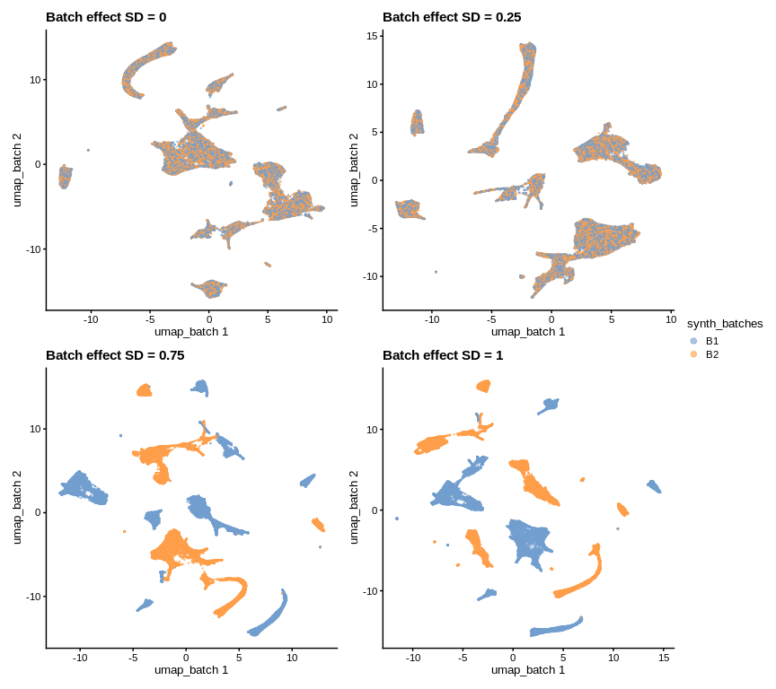

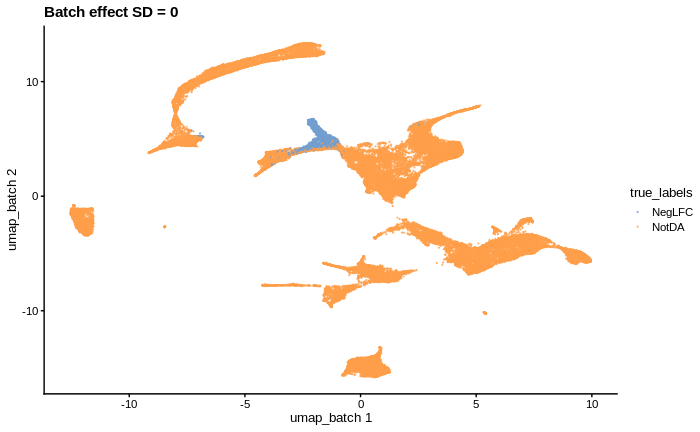

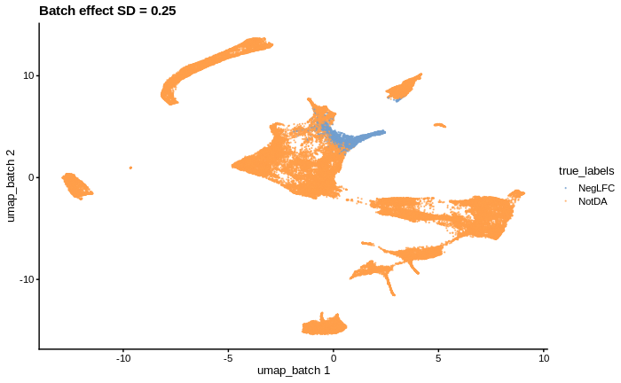

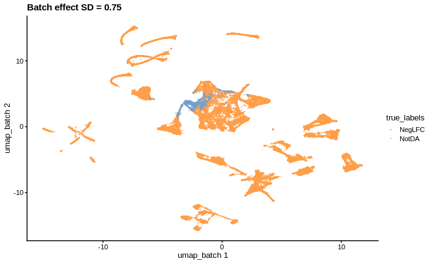

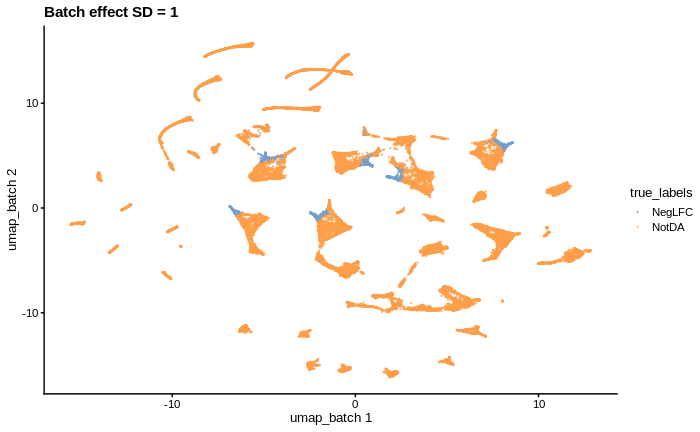

```r
lapply(bm_sce_ls, function(x) plotReducedDim(x, dimred="umap_batch", colour_by="true_labels", point_size=0.2) +
         ggtitle(paste0("Batch effect SD = ", x$norm_sd[1])))
```

### Load results from `run_batch_benchmark.R`

```r
library(glue)
read_benchmark <- function(outdir, pop, seed){
  benchmark_df <- lapply(list.files(outdir, pattern = glue('pop_{pop}_.+{seed}.+.csv'), full.names = TRUE), function(x) read_csv(x)) %>%
  purrr::reduce(bind_rows) %>%
  ## Flip results for DAseq and MELD
  mutate(pred=case_when(method %in% c("meld", 'daseq') & pred=="PosLFC" ~ "NegLFC",
                        method %in% c("meld", 'daseq') & pred=="NegLFC" ~ "PosLFC",
                        TRUE ~ pred))

  # if ('milo_batch' %in% colnames(benchmark_df)){
  #     benchmark_df <- benchmark_df %>%
  #       pivot_wider(id_cols =  - c(method, pred), names_from="method", values_from=pred) %>%
  #       pivot_longer(cols = c(milo, milo_batch, daseq, meld, louvain), names_to='method', values_to="pred")
  # }
  benchmark_df
}

outdir <- "/nfs/team205/ed6/data/milo_benchmark/"
cardio_df <- read_benchmark(outdir, "Cardiomyocytes", seed=2025)
alla_df <- read_benchmark(outdir, "Allantois", seed=2025)
ery_df <- read_benchmark(outdir, "Erythroid1", seed=2025)

# bm_confusion <-
#   cardio_df %>%
#   group_by(method, batch_sd, pop_enr, pred, true) %>%
#   summarise(count=n())
#
# bm_confusion %>%
#   ggplot(aes(pred, true, fill=log(count))) +
#   geom_tile() +
#   facet_grid(method ~ batch_sd) +
#   scale_fill_viridis_c()
```

Visualize results on UMAP

```r
for (m in unique(df$method)){
  embryo_sce$true_labels <- df[df$method==m & df$batch_sd==0,][["true"]]
  embryo_sce$pred_labels <- df[df$method==m & df$batch_sd==0,][["pred"]]
  embryo_sce$true_clust <- df[df$method==m & df$batch_sd==0,][["true_clust"]]
  embryo_sce$true_prob <- df[df$method==m & df$batch_sd==0,][["true_prob"]]
  print(plotReducedDim(embryo_sce, dimred="UMAP", colour_by="pred_labels", point_size=0.2) + ggtitle(m))
}
```

[output not shown]

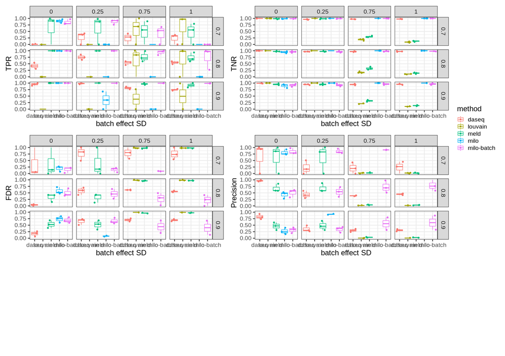

```r
## Calculate evaluation metrics
bm_outcome <- bind_rows(cardio_df, alla_df, ery_df) %>%
  mutate(method=str_c(method, "_",batch_sd, "_", pop, "_", pop_enr)) %>%
  calculate_outcome()
pl_ls <- lapply(c("TPR", "TNR", "FDR", "Precision"), function(metric){
  bm_outcome %>%
  mutate(FDR = FP/(TP+FP)) %>%
  mutate(method=str_replace(method, "_batch", '-batch')) %>%
  separate(col = "method", into = c("method", "be_sd", "pop","pop_enr"), sep = "_") %>%
  rename(metric=metric) %>%
  ggplot(aes(method, metric, color=method)) +
  geom_boxplot(alpha=0.8) +
    geom_jitter() +
  # geom_line() +
    # geom_smooth() +
  ylab(metric) +
  xlab('batch effect SD') +
  facet_grid(pop_enr~be_sd) +
  theme_bw(base_size = 18) +
    ylim(0,1)

})

wrap_plots(pl_ls, nrow=3, ncol=2, guides="collect")
```

[figure not shown]

```r
pl_ls <- lapply(c("TPR", "TNR", "FDR", "Precision"), function(metric){
  bm_outcome %>%
  mutate(FDR = FP/(TP+FP)) %>%
  mutate(method=str_replace(method, "_batch", '-batch')) %>%
  separate(col = "method", into = c("method", "be_sd", "pop","pop_enr"), sep = "_") %>%
  rename(metric=metric) %>%
  ggplot(aes(be_sd, metric, color=method)) +
  geom_point() +
  # geom_line() +
    geom_smooth() +
  ylab(metric) +
  xlab('batch effect SD') +
  facet_grid(pop_enr~.) +
  theme_bw(base_size = 18) +
    ylim(0,1)

})

wrap_plots(pl_ls, nrow=3, ncol=2, guides="collect")
```

[figure not shown]

```r
pl_ls <- lapply(c("TPR", "FPR", "FNR", "TNR", "Precision"), function(metric){
  bm_outcome %>%
  mutate(method=str_replace(method, "_batch", '-batch')) %>%
  separate(col = "method", into = c("method", "be_sd", "pop","pop_enr"), sep = "_") %>%
  mutate(pop_enr=as.numeric(pop_enr)) %>%
  filter(be_sd==0) %>%
  rename(metric=metric) %>%
  ggplot(aes(method, metric, color=method)) +
  # geom_tile() +
  ggbeeswarm::geom_quasirandom(size=3, alpha=0.8) +
  # geom_line() +
  ylab(metric) +
    scale_fill_viridis_c(limits=c(0,1)) +
  xlab('Effect size') +
  facet_grid(.~pop_enr) +
  theme_bw(base_size = 18) +
  ylim(0,1)

})

wrap_plots(pl_ls, nrow=3, ncol=2, guides = "collect")
```

Vary threshold for true DA

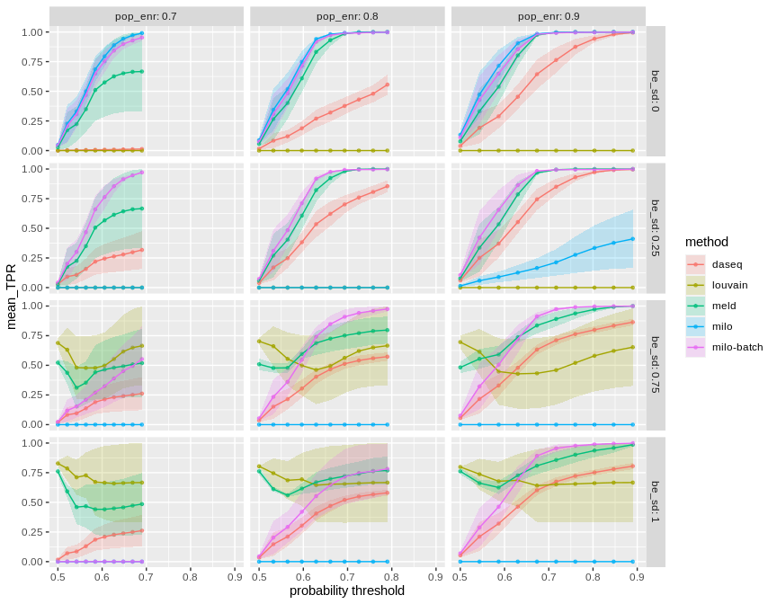

```r
bind_rows(pr_df_07,pr_df_08,pr_df_09) %>%
  mutate(FDR = FP/(TP+FP)) %>%
  mutate(method=str_replace(method, "_batch", '-batch')) %>%
  separate(col = "method", into = c("method", "be_sd", "pop","pop_enr"), sep = "_") %>%
  mutate(TPR=ifelse(is.nan(TPR), 0, TPR),
         FPR=ifelse(is.nan(FPR), 0, FPR),
         Precision=ifelse(is.nan(Precision), 0, Precision)) %>%
  group_by(method, DA_thresh, be_sd, pop_enr) %>%
  summarise(mean_TPR=mean(TPR), mean_FDR=mean(FDR),
            sd_TPR=sd(TPR)/sqrt(n()), sd_FDR=sd(FDR)) %>%
  # filter(method=="daseq") %>%
  # mutate(group_pop=paste(pop, method)) %>%
  ggplot(aes(DA_thresh, mean_TPR, color=method)) +
  geom_point(size=1, alpha=0.7) +
  geom_ribbon(aes(ymin=mean_TPR-sd_TPR, ymax=mean_TPR+sd_TPR, fill=method), alpha=0.2, color=NA) +
  geom_line() +
  facet_grid(be_sd~pop_enr, labeller="label_both") +
  xlab("probability threshold") +
  xlim(0.5,0.9)
```

## Simulate batch effects with decent design

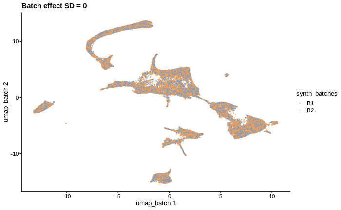

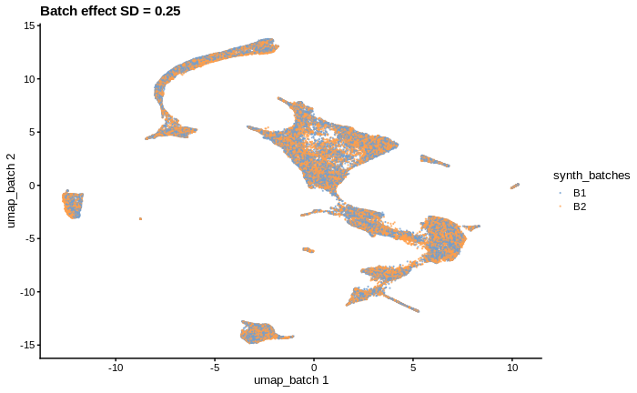

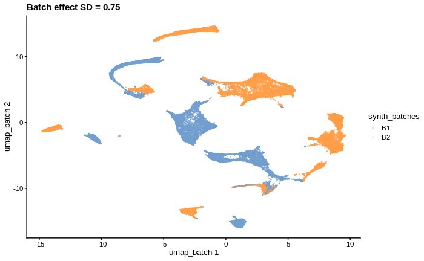

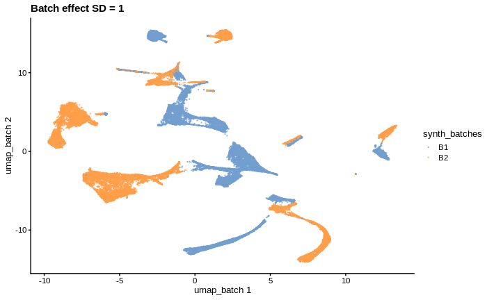

```r
bm_sce_ls <- lapply(bm_sce_ls, function(x) runUMAP(x, dimred="pca_batch", name = 'umap_batch', n_dimred=1:30))

lapply(bm_sce_ls, function(x) plotReducedDim(x, dimred="umap_batch", colour_by="synth_batches", point_size=0.2) +
         ggtitle(paste0("Batch effect SD = ", x$norm_sd[1])))
```

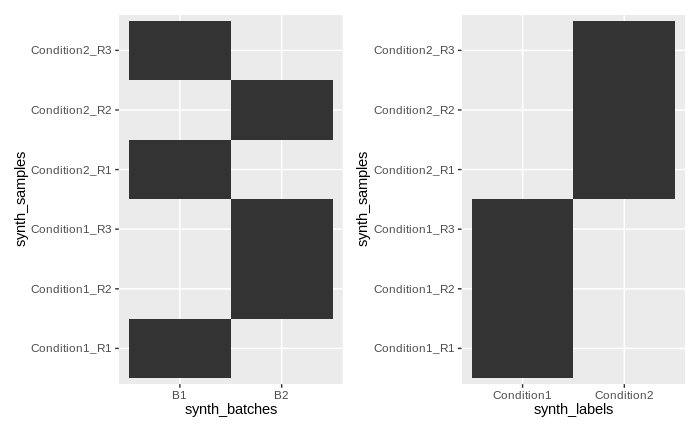

```r
data.frame(colData(bm_sce_ls[[1]])[c("synth_labels", "synth_samples", "synth_batches")]) %>%
  distinct() %>%
  ggplot(aes(synth_batches, synth_samples)) +
  geom_tile() +
data.frame(colData(bm_sce_ls[[1]])[c("synth_labels", "synth_samples", "synth_batches")]) %>%
  distinct() %>%
  ggplot(aes(synth_labels, synth_samples)) +
  geom_tile()
```

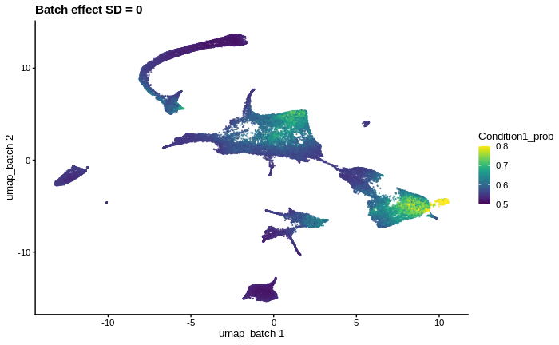

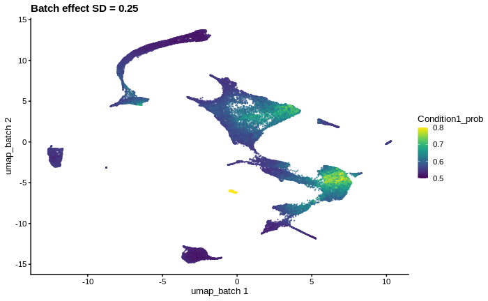

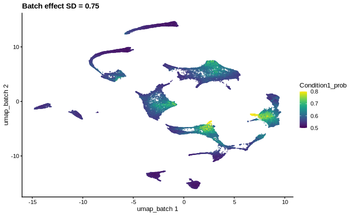

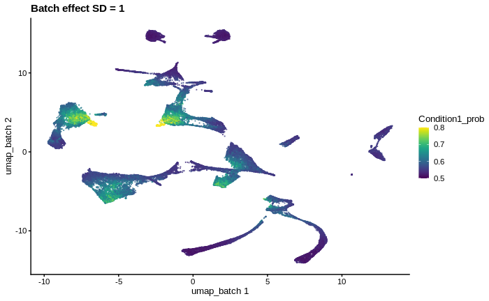

```r
lapply(bm_sce_ls, function(x) plotReducedDim(x, dimred="umap_batch", colour_by="Condition1_prob", point_size=0.2) +
         ggtitle(paste0("Batch effect SD = ", x$norm_sd[1])))
```

Try Milo with technical covariate in design

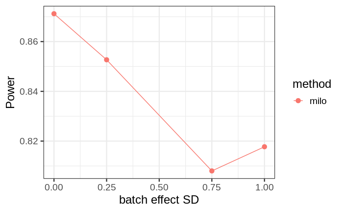

```r
purrr::reduce(milo_res_ls, bind_rows) %>%
  mutate(method=str_c(method, "_",batch_sd)) %>%
  calculate_outcome() %>%
  separate(col = "method", into = c("method", "be_sd"), sep = "_") %>%
  ggplot(aes(as.numeric(be_sd), Power, color=method)) +
  geom_point(size=3) +
  geom_line() +
  xlab('batch effect SD') +
  theme_bw(base_size = 18)
```

## Generate synthetic labels

make probability of being in condition 1 or 2 (Translating code from scOpenProblems)

```r
# Given a data_embedding, sample a simplex to weight each dimension to get a
# new PDF for each condition
# a: scaling coefficient in logit (lower a --> less extreme probabilities)
.make_pdf <- function(data_embedding, a=0.2){
  # Create an array of values that sums to 1
  n_components = ncol(data_embedding)
  data_simplex = sort(runif(n = n_components-1))
  data_simplex = c(0, data_simplex, 1)
  data_simplex = diff(data_simplex)
  data_simplex = sample(data_simplex)
  # Weight each embedding component by the simplex weights
  sort_axis = rowSums(data_embedding * data_simplex)

  # Pass the weighted components through a logit
  pdf = 1/(1+exp(- a * sort_axis))
  if (sample(c(TRUE, FALSE), 1)){ pdf = 1 - pdf }
  return(pdf)
  }

## Smooth probabilities over KNN graph (to avoid having clusters with opposite sign DA)
.knn_smoothing <- function(graph, cond_probability, k=15, redDim='pca.corrected', d=10){
  # X_red_dim = reducedDim(sce, redDim)[,1:d]
  # graph = buildKNNGraph(t(X_red_dim), k = k)
  adj = get.adjacency(graph)
  smooth_cond_probability <- (adj %*% cond_probability)/rowSums(adj)
  smooth_cond_probability
}

# Creates random differentially expressed regions over a dataset for benchmarking.
add_synthetic_labels <- function(sce, # SingleCellExperiment obj
                                 knn_graph, # for knn smoothing of probability values
                                 redDim='pca.corrected', # embedding to use to simulate differential abundance
                                 n_conditions=2, # number of conditions to simulate
                                 n_components=10, # number of components of embedding to use
                                 seed=42
                                 ){
  data_embedding = reducedDim(sce, redDim)[,1:n_components]
  set.seed(seed)
  # embedding data must be mean-centered
  data_embedding = t(scale(t(data_embedding), scale=FALSE))

  # Randomly flip sign of each embedding dimension
  data_embedding = apply(data_embedding, 2, function(x)  x*sample(c(-1, 1), 1) )

  conditions = paste0("Condition", 1:n_conditions)
  cond_probability = sapply(1:(length(conditions)-1), function(x) .make_pdf(data_embedding))

  # KNN Smoothing to avoid regions of the graph with opposite labels
  cond_probability = .knn_smoothing(knn_graph, cond_probability, redDim=redDim, d=n_components)

  # Normalize to sum to 1 for each cell
  # cond_probability <- t(apply(cond_probability, 1, function(x) x/sum(abs(x))))
  cond_probability = cbind(cond_probability, 1 - rowSums(cond_probability))
  colnames(cond_probability) = conditions

  # Generate labels for condition and replicates
  synth_labels <- sapply(1:nrow(cond_probability),  function(i) sample(colnames(cond_probability), size = 1, prob = cond_probability[i,]))
  synth_replicates <- rep(c("R1", "R2", "R3" ), 1000)
  synth_samples <- paste0(synth_labels, "_", synth_replicates)

  # Add synthetic labels and probabilities to colData
  colData(sce)[["synth_labels"]] <- synth_labels
  # colData(sce)[["synth_replicates"]] <- synth_replicates
  colData(sce)[["synth_samples"]] <- synth_samples
  colnames(cond_probability) <- paste0(colnames(cond_probability), "_prob")
  colData(sce)[colnames(cond_probability)] <- cond_probability
  return(sce)
  }

# Build KNN graph for smoothing
X_red_dim = reducedDim(embryo_sce, "pca.corrected")[,1:50]
graph = buildKNNGraph(t(X_red_dim), k = k)

embryo_sce <- add_synthetic_labels(embryo_sce, n_components = 10,  redDim='pca.corrected', seed=42, knn_graph = graph)
```

```r
plotReducedDim(embryo_sce, "UMAP", colour_by="Condition1_prob", point_size=0.1)
plotReducedDim(embryo_sce, "UMAP", colour_by="Condition2_prob", point_size=0.1)

plotReducedDim(embryo_sce, "UMAP", colour_by="synth_labels", point_size=0.1) + facet_wrap(colour_by~.)
plotReducedDim(embryo_sce, "UMAP", colour_by="synth_samples", point_size=0.1)

true_labels <- ifelse(embryo_sce$Condition2_prob < 0.4, "NegLFC", ifelse(embryo_sce$Condition2_prob > 0.6, "PosLFC", "NotDA"))
colData(embryo_sce)[["true_labels"]] <- true_labels
plotReducedDim(embryo_sce, "UMAP", colour_by="true_labels", point_size=0.1)
```

## Picking parameters

Test how robust alternative methods are to parameter choices

```r
## Run MELD
bm_meld <- function(sce, k, d){
  meld_res <- run_meld_reticulate(sce, condition_col="synth_labels", sample_col="synth_samples", reduced.dim = "pca.corrected", d=d, k=k)
  meld_out <- meld2output(meld_res, out_type = 'labels')
  bm <- data.frame(meld=meld_out)
  bm$true_prob <- sce$Condition2_prob
  bm$true <- sce$true_labels
  long_bm <- pivot_longer(bm, cols = c(meld), names_to='method', values_to="pred")
  long_bm$k <- k
  long_bm$d <- d
  long_bm
}

true_labels <- ifelse(embryo_sce$Condition2_prob < 0.4, "NegLFC", ifelse(embryo_sce$Condition2_prob > 0.6, "PosLFC", "NotDA"))
colData(embryo_sce)[["true_labels"]] <- true_labels

meld_bm_ls <- lapply(c(10,15,20), function(k) bm_meld(embryo_sce, k, 30))
```

## Benchmark on synthetic labels

```r
long_bm <- benchmark_da(embryo_sce, out_type = "labels")
```

```r
long_bm %>%
  ggplot(aes(true, pred)) +
  geom_bin2d() +
  facet_wrap(method~.)
```

```r
long_bm %>%
  ggplot(aes(pred, true_prob)) +
  # ggbeeswarm::geom_quasirandom() +
  geom_boxplot(varwidth=TRUE) +
  # geom_violin() +.
  facet_wrap(method~.)
```

```r
calculate_outcome(long_bm)
```

```r
long_bm <- mutate(long_bm, true=ifelse(true_prob < 0.4, "NegLFC", ifelse(true_prob > 0.6, "PosLFC", "NotDA")))

calculate_outcome(long_bm)
```

## Add batch effect

Problems: * I don’t have batch corrected counts here, I need to add batch effects to PCs

```r
add_batch_effect <- function(embryo_sce, norm_sd=0.5, seed=42){
  cellids_sample <- split(embryo_sce$cell, embryo_sce$synth_samples)
  X_pca <- reducedDim(embryo_sce, "pca.corrected")
  X_pca_batch <- X_pca

  set.seed(42)
  for (b in names(cellids_sample)){
    batch_effect <- rnorm(ncol(X_pca), mean=0, sd = norm_sd)
    X_pca_batch[cellids_sample[[b]],] <- t(apply(X_pca_batch[cellids_sample[[b]],], 1, function(x) x + batch_effect))
    }

  reducedDim(embryo_sce, "pca_batch") <- X_pca_batch
  embryo_sce
  }

# plotReducedDim(embryo_sce, "pca.corrected", colour_by="synth_samples", ncomponents = 1:2, point_size=0.2)
```

```r
embryo_sce <- scater::runUMAP(embryo_sce, dimred="pca_batch", name = 'umap_batch', n_dimred=1:30)

plotReducedDim(embryo_sce, "umap_batch", colour_by="Condition2_prob", point_size=0.1)
plotReducedDim(embryo_sce, "umap_batch", colour_by="synth_labels", point_size=0.1) + facet_wrap(colour_by~.)
plotReducedDim(embryo_sce, "umap_batch", colour_by="synth_samples", point_size=0.1)
```

```r
bm_batch <- benchmark_da(embryo_sce[,1:5000], red_dim = "pca_batch", out_type = "labels")
true_labels <- ifelse(embryo_sce[,1:5000]$Condition2_prob < 0.4, "NegLFC", ifelse(embryo_sce[,1:5000]$Condition2_prob > 0.6, "PosLFC", "NotDA"))
bm_batch$true_prob <- embryo_sce[,1:5000]$Condition2_prob
bm_batch$true <- true_labels
long_bm_batch <- bm_batch %>%
  pivot_longer(cols = c(milo, daseq, meld, louvain), names_to='method', values_to="pred")
```

```r
long_bm_batch %>%
  ggplot(aes(true, pred)) +
  geom_bin2d() +
  facet_wrap(method~.)
```

```r
long_bm_batch %>%
  ggplot(aes(pred, true_prob)) +
  # ggbeeswarm::geom_quasirandom() +
  geom_boxplot(varwidth=TRUE) +
  # geom_violin() +.
  facet_wrap(method~.)

long_bm %>%
  ggplot(aes(pred, true_prob)) +
  # ggbeeswarm::geom_quasirandom() +
  geom_boxplot(varwidth=TRUE) +
  # geom_violin() +.
  facet_wrap(method~.)
```

```r
bm_ls <- lapply(c(0, 0.1, 0.5, 1), function(sd){
  sce_be <- add_batch_effect(embryo_sce, norm_sd=sd)
  long_bm <- benchmark_da(sce_be, out_type = "labels", red_dim = "pca_batch")
  # outcome <- calculate_outcome(long_bm)
  mutate(long_bm, batch_sd=sd)
  })

purrr::reduce(bm_ls, bind_rows) %>%
  ggplot(aes(batch_sd, Accuracy, color=method)) +
  geom_point(size=3) +
  theme_bw(base_size=16)

purrr::reduce(bm_ls, bind_rows) %>%
  ggplot(aes(batch_sd, FPR, color=method)) +
  geom_point(size=3) +
  theme_bw(base_size=16)
```